# multi-level-modelling

Freya Watkins

18 January 2022

Load tidyverse:

```r
library(tidyverse)
```

# Multilevel Modelling in R

## Tutorial Video 1: Unconditional *Means* Model (Null Model)

[video](https://www.youtube.com/watch?v=cr9RpSgRYVw)

The unconditional means model is the null model, which includes no predictors (independent variables) or measures of time. Running the unconditional means model is to test the significance of the grand mean and intercept of your model. Building the unconditional means model is the first step in analyzing longitudinal data using multilevel modeling.

Research Q: Can we reject the NULL hyp. that the grand mean for the intercept is equal to zero?

### STEP 1: Read in dataset

Make sure file is a .csv and not a .xls worksheet Make sure data is in long format, i.e. multiple rows per ppt per session.

```r
apt <- read.csv("data/2021-09-30_SLI_aptitude_data.csv")
```

!!! BEGIN TIMEPOINTS WITH 0, not 1 !!! else you would be skewing your results.

```r
names(apt)
```

```
##  [1] "ï..session"  "group"       "ppt"         "nback_lett"  "nback_spat"
##  [6] "nback_comb"  "corsi_bspan" "corsi_score" "corsi_corr"  "corsi_mspan"
## [11] "kirk_ceil"   "kirk_raw"    "kirk_acc"    "kbit_ceil"   "kbit_raw"
## [16] "kbit_acc"    "dspan_mem"   "dspan_corr"  "dspan_time"  "mr2d_acc"
## [21] "mr2d_rt"     "mr3d_acc"    "mr3d_rt"     "bis_tot"     "bis_att"
## [26] "bis_mot"     "bis_nplan"   "mlat_raw"    "mlat_acc"    "summ"
## [31] "copy_sign"   "bsl_srt"     "town_map"    "grade_bsl"   "grade_terp"
## [36] "comments"
```

```r
apt <- dplyr::rename(apt, session = "ï..session") # fix

# shift so that 1st session=0
apt$session <- apt$session-1
apt$session # check
```

```
##  [1] 0 0 0 0 0 0 0 0 0 0 0 0 0 0 0 0 0 0 0 0 0 0 0 0 0 0 0 0 0 0 0 0 0 1 1 1 1 1
## [39] 1 1 1 1 1 1 1 1 1 1 1 1 1 1 1 1 1 1 1 1 1 1 1 1 1 1 1 1 2 2 2 2 2 2 2 2 2 2
## [77] 2 2 2 2 2 2 2 2 2 2 2 2 2 2 2 2 2 2 2 2 2 2 2
```

```r
# replace HW or WV code with nothing
apt$ppt <- gsub("HW|WV", "", apt$ppt)
apt$ppt <- as.numeric(apt$ppt)

# try with values above 1
apt$nback_lett <- apt$nback_lett * 100
```

### STEP 2: Open {nlme} package

nlme: linear and nonlinear mixed effects models

```r
library(nlme)
```

There are other packages available incl. {lme4}

### STEP 3: Examine head of data

```r
head(apt)
```

```
##   session group ppt nback_lett nback_spat nback_comb corsi_bspan corsi_score
## 1       0 pilot   1         68       0.76       0.72           5          35
## 2       0 pilot   5         75       0.73       0.74           8          88
## 3       0 pilot   6         67       0.75       0.71           6          54
## 4       0 pilot   7         73       0.71       0.72           6          60
## 5       0 pilot   8         75       0.73       0.74           8          80
## 6       0 pilot  13         68       0.71       0.70           6          60
##   corsi_corr corsi_mspan kirk_ceil kirk_raw kirk_acc kbit_ceil kbit_raw
## 1          7         4.5        38       30     0.79        38       33
## 2         11         6.5        39       38     0.97        45       42
## 3          9         5.5        33       30     0.91        40       40
## 4         10         6.0        40       30     0.75        43       39
## 5         10         6.0        38       33     0.87        45       45
## 6         10         6.0        42       31     0.74        46       39
##   kbit_acc dspan_mem dspan_corr dspan_time mr2d_acc mr2d_rt mr3d_acc mr3d_rt
```

[output cut: 20 more lines]

### STEP 4: Run unconditional means model (UMM) w/ summary

We are using ppt as the nested variable/random effect, i.e. ppts are nested within themselves compared at diff time points. Some might think to use e.g. group or uni as the random effect since it is another level of clustering, but this is a longitudinal design, so must be nested based on individuals. The first ~1 refers to no slope/random effects at this point

```r
# select relevant cols, remove NA rows
nback1 <- apt %>% select(session, ppt, nback_lett) %>% filter(nback_lett != "NA")
```

```r
mod1 <- lme(nback_lett~1, random=~1|ppt, data=nback1, method="ML")

summary(mod1)
```

```
## Linear mixed-effects model fit by maximum likelihood
##   Data: nback1
##        AIC      BIC    logLik
##   330.8459 336.9219 -162.4229
##
## Random effects:
##  Formula: ~1 | ppt
##         (Intercept) Residual
## StdDev:    2.088573 3.927826
##
## Fixed effects:  nback_lett ~ 1
##                Value Std.Error DF  t-value p-value
## (Intercept) 71.65711 0.6540319 33 109.5621       0
##
## Standardized Within-Group Residuals:
##        Min         Q1        Med         Q3        Max
## -2.8730052 -0.5947509  0.0726023  0.6634834  1.4700610
##
## Number of Observations: 56
## Number of Groups: 33
```

IMPORTANT NOTES ABOUT THIS MODEL - No predictors in the model (no independent variables) - This is the null model (beginning of intercept only) - Time is not being measured within this model - Measuring the grand mean here

### STEP 5: Run intervals for the unconditional means model

```r
intervals(mod1)
```

```
## Approximate 95% confidence intervals
##
##  Fixed effects:
##               lower     est.    upper
## (Intercept) 70.3384 71.65711 72.97581
## attr(,"label")
## [1] "Fixed effects:"
##
##  Random Effects:
##   Level: ppt
##                     lower     est.    upper
## sd((Intercept)) 0.8041238 2.088573 5.424707
##
##  Within-group standard error:
##    lower     est.    upper
## 2.961625 3.927826 5.209240
```

### STEP 6: Calculate intra-class correlation coefficient for the UMM

For participants:

```r
# have to manually calculate
(0.02088573^2) / ((0.02088573^2) + (0.03927826^2))
```

```
## [1] 0.2204218
```

We get 0.2204218. So 22% variability exists. So a bit of clustering is taking place. We need to flush it out by selecting a proper slope and then by using our predictors to see how much of that variability we can account for. If this value were <.05, would suggest no clustering is happening and MLM would be less appropriate.

So here we’re not testing any hypothesis at this point. Just looking to see how much the interval differs from 0. We can use the I-CCC to see if we should proceed with multi-level modelling.

## Tutorial Video 2: Unconditional *Growth* Model (Setting up the slope)

[video](https://www.youtube.com/watch?v=XvO9p5LVjrU)

The unconditional growth model includes a measure of time across a slope (either being a fixed or a random slope). By running the unconditional growth model, we can test the appropriateness of the slope, and whether the slope for the model should be fixed or random. The unconditional growth model can also be compared with the unconditional means model for “model fit”. The unconditional growth model does not include any other predictors (independent variables). All other predictors will be included in the condition growth model, which is the full model.

In the 1st section we saw the UMM follows the assumption that everyone is following a similar pattern. But random slopes allow for individual variability e.g. over time. Now we’re going to test the slope to see if it will be fixed or random.

Going back to the RQ, we only looked at the dependent variable. Now we can include a time variable, i.e. Session. This will help us set up the slope. So after running both a model with fixed slopes and one with random slopes, we can compare to see which one significantly differs from the UMM.

### STEPS 1-3: Same as Tutorial one

Load and inspect data

### STEP 4: Begin plotting the data to see individual slopes

We want to determine whether Session should have a fixed or random slope

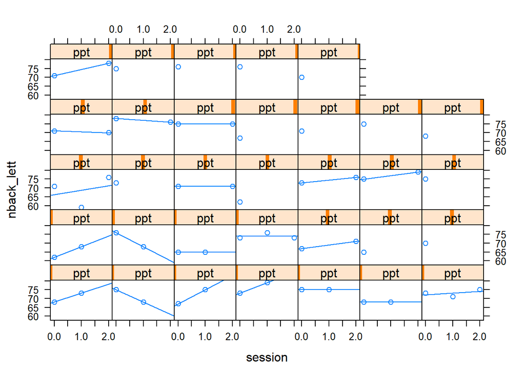

```r
library(lattice)

xyplot(nback_lett ~ session | ppt,
       data = nback1, type = c("p", "r"))
```

So we can see some improve, some get worse over time. Looks like we clearly want random slopes, but let’s try both anyway

### STEP 5: Run the unconditional growth models

#### a) Unconditional growth model (mod2) - Session as a fixed slope

```r
mod2 <- lme(nback_lett ~ session, random=~1|ppt,
            data = nback1, method = "ML")
summary(mod2)
```

```
## Linear mixed-effects model fit by maximum likelihood
##   Data: nback1
##        AIC      BIC    logLik
##   329.4651 337.5665 -160.7326
##
## Random effects:
##  Formula: ~1 | ppt
##         (Intercept) Residual
## StdDev:    2.073516 3.790717
##
## Fixed effects:  nback_lett ~ session
##                Value Std.Error DF  t-value p-value
## (Intercept) 70.95314 0.7485904 32 94.78233  0.0000
## session      1.24111 0.6767905 22  1.83382  0.0802
##  Correlation:
##         (Intr)
## session -0.512
##
## Standardized Within-Group Residuals:
##        Min         Q1        Med         Q3        Max
## -3.0404847 -0.6179746  0.1576713  0.7815935  1.3843512
##
## Number of Observations: 56
## Number of Groups: 33
```

Now let’s run the confidence intervals

```r
intervals(mod2)
```

```
## Approximate 95% confidence intervals
##
##  Fixed effects:
##                  lower      est.     upper
## (Intercept) 69.4557878 70.953140 72.450492
## session     -0.1371744  1.241111  2.619397
## attr(,"label")
## [1] "Fixed effects:"
##
##  Random Effects:
##   Level: ppt
##                     lower     est.    upper
## sd((Intercept)) 0.8221366 2.073516 5.229628
##
##  Within-group standard error:
##    lower     est.    upper
## 2.852004 3.790717 5.038400
```

We can see they’re not significant because the fixed effects lower CI is negative whereas the others are positive = not significant. So session as a fixed slope is not significant. Interestingly when we look at the random effects, these are still significant. All values are positive. So we can see right away that the random effects are significant. This is promising, which suggests we can structure the model in a better way. So now let’s do it with session as a random slope

#### b) Unconditional growth model (mod3) - Session as a random slope

This model accounts for individual variability

```r
mod3 <- lme(nback_lett~session,random=~session|ppt,data=nback1,method="ML")
summary(mod3)
```

```
## Linear mixed-effects model fit by maximum likelihood
##   Data: nback1
##        AIC      BIC    logLik
##   333.4651 345.6172 -160.7326
##
## Random effects:
##  Formula: ~session | ppt
##  Structure: General positive-definite, Log-Cholesky parametrization
##             StdDev      Corr
## (Intercept) 2.073516111 (Intr)
## session     0.000281777 0
## Residual    3.790716968
##
## Fixed effects:  nback_lett ~ session
##                Value Std.Error DF  t-value p-value
## (Intercept) 70.95314 0.7485904 32 94.78233  0.0000
## session      1.24111 0.6767905 22  1.83382  0.0802
##  Correlation:
##         (Intr)
## session -0.512
##
## Standardized Within-Group Residuals:
##        Min         Q1        Med         Q3        Max
## -3.0404847 -0.6179745  0.1576713  0.7815935  1.3843512
##
## Number of Observations: 56
## Number of Groups: 33
```

```r
# intervals(mod3)
```

This gives an error: “cannot get confidence intervals on var-cov components”. Not sure why

In the tutorial dataset, the model with session as a random slope is clearly preferred, as the two groups sharply contrast in their performance based on training peformance overtime. Maybe there isn’t enough variation among my participants in change over time, so possibly a fixed slope for time is fine after all?

We can see if the models differ by running anovas (mod 1 vs mod 2; mod 1 vs mod 3).

## STEP 6: Run deviance statistics.

### a) First, rerun the unconditional means model (mod1) from before:

```r
mod1 <- lme(nback_lett~1, random=~1|ppt, data=nback1, method="ML")
summary(mod1)
```

```
## Linear mixed-effects model fit by maximum likelihood
##   Data: nback1
##        AIC      BIC    logLik
##   330.8459 336.9219 -162.4229
##
## Random effects:
##  Formula: ~1 | ppt
##         (Intercept) Residual
## StdDev:    2.088573 3.927826
##
## Fixed effects:  nback_lett ~ 1
##                Value Std.Error DF  t-value p-value
## (Intercept) 71.65711 0.6540319 33 109.5621       0
##
## Standardized Within-Group Residuals:
##        Min         Q1        Med         Q3        Max
## -2.8730052 -0.5947509  0.0726023  0.6634834  1.4700610
##
## Number of Observations: 56
## Number of Groups: 33
```

```r
intervals(mod1)
```

```
## Approximate 95% confidence intervals
##
##  Fixed effects:
##               lower     est.    upper
## (Intercept) 70.3384 71.65711 72.97581
## attr(,"label")
## [1] "Fixed effects:"
##
##  Random Effects:
##   Level: ppt
##                     lower     est.    upper
## sd((Intercept)) 0.8041238 2.088573 5.424707
##
##  Within-group standard error:
##    lower     est.    upper
## 2.961625 3.927826 5.209240
```

### b) Compare UMM to UGM with a fixed slope (mod 2)

```r
(results <- anova(mod1,mod2))
```

```
##      Model df      AIC      BIC    logLik   Test  L.Ratio p-value
## mod1     1  3 330.8459 336.9219 -162.4229
## mod2     2  4 329.4651 337.5665 -160.7326 1 vs 2 3.380745   0.066
```

```r
results$`p-value`
```

```
## [1]         NA 0.06596222
```

It’s not significant (just!) p = .066 The log-Lik values are fairly similar So possibly having a fixed slope has marginally improved fit of data

### c) Compare UMM to UGM with a random slope (mod 3)

```r
(results <- anova(mod1,mod3))
```

```
##      Model df      AIC      BIC    logLik   Test  L.Ratio p-value
## mod1     1  3 330.8459 336.9219 -162.4229
## mod3     2  6 333.4651 345.6172 -160.7326 1 vs 2 3.380745  0.3366
```

```r
results$`p-value`
```

```
## [1]        NA 0.3365616
```

Also not significant p = .336 In the tutorial, the p-value was very significant, suggesting a random slope had really improved the model fit to the data.

## STEP 7: Calculate intra-class correlation coefficient (ICC) for each model

ICC for UMM (mod1):

```r
variance.partitions <- VarCorr(mod1)
between.v <- as.numeric(variance.partitions[1,1])
within.v <- as.numeric(variance.partitions[2,1])
ICC.estimate  <- between.v/ (between.v + within.v)
print(ICC.estimate)
```

```
## [1] 0.2204217
```

Some clustering taking place in the data (0.22) suggesting a multi level modelling is appropriate

ICC for UMM (mod2):

```r
variance.partitions <- VarCorr(mod2)
between.v <- as.numeric(variance.partitions[1,1])
within.v <- as.numeric(variance.partitions[2,1])
ICC.estimate  <- between.v/ (between.v + within.v)
print(ICC.estimate)
```

```
## [1] 0.2302999
```

Similar ICC with a fixed slope (0.23)

ICC for UMM (mod3)

```r
variance.partitions <- VarCorr(mod3)
between.v <- as.numeric(variance.partitions[1,1])
within.v <- as.numeric(variance.partitions[2,1])
ICC.estimate  <- between.v/ (between.v + within.v)
print(ICC.estimate)
```

```
## [1] 1
```

Once we add a random slope, the clustering has gone up even higher. But 1 is too high, surely! We can’t be accounting for 100% of the variability in the clustering. This may be why the intervals are not working

## Tutorial Video 3: *Conditional Growth* Model (Full Model)

[video](https://www.youtube.com/watch?v=wVI5-iqOpLA)

The conditional growth model, which is full model, is built upon the unconditional growth model, which establishes a measure of time across a slope (either being a fixed or a random slope). The conditional growth model includes all predictors (independent variables) of the dependent variable or outcome. If you have specific hypotheses or research questions about your longitudinal data, this would be the stage at which you could begin to include your predictors within the model. By running the conditional growth model, we can test our research questions and examine interactions between predictors on the dependent variable. We can also compare the conditional growth model (full model) to the unconditional growth model (with slope) for “model fit” and examine the predictive power of our independent variables.